# Data_Simulation

Sunny

May 12, 2016

## Background

The genetic disorder phenylketonuria (PKU) is the inability to metabolize phenylalanine because of a lack of the enzyme phenylalanine(Phe) hydroxylase. Individuals with this disorder are known as “phenylketonurics” and must regulate their intake of phenylalanine, an essential amino acid that support our body to remain healthy. The paper that this project based on is: (paper)

```
Relation of Prenatal Phenylalanine Exposure to Infant and Childhood Cognitive Outcomes:
         Results From the International Maternal PKU Collaborative Study
                           Widaman, K. & Azen, C. (2003).
                     Pediatrics, 112(Supplement 4), 1537-1543
 Retrieved from http://pediatrics.aappublications.org/content/112/Supplement_4/1537.
```

It studied 412 children and their mothers from the International Maternal PKU Collaborative Study on their prenatal Phe exposure to the effect on offstrings intellectual development.

The goal of this project is to simulate the data and replicate the study on relation of prenatal Phenylalanine exposure to infant and childhood cognitive outcomes. In addition, developmental relations of maternal demographic, pregnancy-related, and prenatal variables on offspring intelligence will also be examined.

## Methods

### Software and Packages

`R` is used for all procedures related to data.  
Packages used:

```r
library(dplyr)
```

```r
library(reshape2)
library(ggplot2)
```

### Data Simulation

Based on the given summary sttistics below on the variables, their distributions will be estimated. In addition, linear combination formulas will be constructed for variables that are obviously related to others (i.g. birth weight is related to mother’s weight gain and baby’s head circumference).

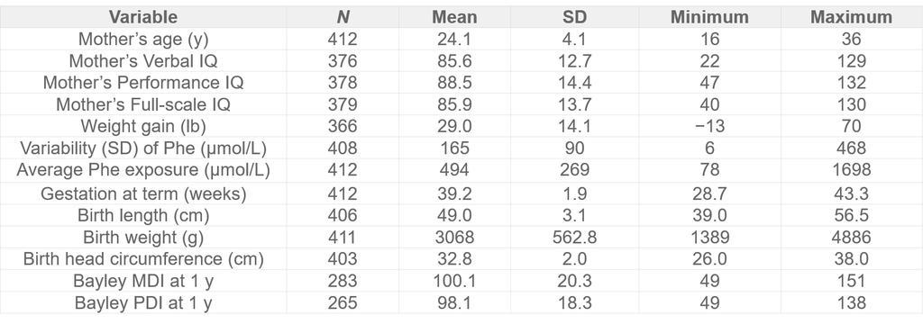

The data simulation function is presented below:

```r
generateData = function(N=412){
  #Random generated variables:
  age = sample(c(runif(412,16,36)),N,replace = T)
  mVIQ = sample(c(abs(105-rweibull(376,2, 45))+22, rep(NA,(412-376))),N,replace = T)
  mPIQ = sample(c(rnorm(378, 88.5,14.4), rep(NA,(412-378))),N,replace = T)
  mIQ = sample(c((mVIQ+mPIQ)/2), N,replace = T)
  gestation = sample(c(45-rweibull(412,1.6,5)),N,replace = T)
  phe_sd = sample(c(rweibull(408,2,188),rep(NA,(412-408))),N, replace = T)
  phe_avg = sample(c(rweibull(412,1.8,610)),N,replace = T)
  # *Missing values are generated as NA proportionally to the real data.

  # Formulated variables based on related variables:
  wt_gain= sample(c(rnorm(366,25.0,14.1),rep(NA,(412-366))),N,replace = T)+0.1*gestation
  birth_len = sample(c(rnorm(406,45.0,3.1),rep(NA,(412-406))),N,replace = T)+0.1*gestation
  head_circum = sample(c(rnorm(403,32.8,2.0),rep(NA,(412-403))),N, replace = T)+0.1*gestation-0.001*phe_avg-2
  birth_wt = 38*gestation+7*head_circum+41*wt_gain
  MDI = 1.5*head_circum+3*gestation-0.012*phe_avg-56.5
  PDI = 1.5*head_circum+2.5*gestation-0.022*phe_avg-40.5

  # Compose into data frame:
  result = data.frame(age, mVIQ, mPIQ, mIQ, wt_gain, phe_sd,
                      phe_avg, gestation, birth_len, birth_wt,
                      head_circum, MDI, PDI)
  return(result)
}
```

Users could generate any number of observations by calling:

```r
data = generateData(1000)
summary(data)
```

```
##       age             mVIQ             mPIQ             mIQ
##  Min.   :16.03   Min.   : 26.49   Min.   : 52.34   Min.   : 52.94
##  1st Qu.:21.42   1st Qu.: 74.62   1st Qu.: 77.11   1st Qu.: 79.50
##  Median :26.56   Median : 91.11   Median : 86.74   Median : 89.19
##  Mean   :26.45   Mean   : 88.32   Mean   : 87.66   Mean   : 88.33
##  3rd Qu.:31.66   3rd Qu.:104.82   3rd Qu.: 97.72   3rd Qu.: 97.86
##  Max.   :35.97   Max.   :125.99   Max.   :128.43   Max.   :121.04
##                  NA's   :83       NA's   :90       NA's   :172
##     wt_gain           phe_sd           phe_avg          gestation
##  Min.   :-12.86   Min.   :  2.662   Min.   :  24.48   Min.   :28.79
##  1st Qu.: 17.80   1st Qu.:103.988   1st Qu.: 299.98   1st Qu.:38.97
##  Median : 28.42   Median :156.644   Median : 488.89   Median :41.12
##  Mean   : 28.39   Mean   :164.267   Mean   : 542.65   Mean   :40.60
##  3rd Qu.: 37.96   3rd Qu.:215.181   3rd Qu.: 716.03   3rd Qu.:42.74
##  Max.   : 66.43   Max.   :496.310   Max.   :1874.34   Max.   :44.85
##  NA's   :132      NA's   :11
##    birth_len        birth_wt     head_circum         MDI
##  Min.   :39.94   Min.   :1284   Min.   :26.91   Min.   : 71.89
##  1st Qu.:46.65   1st Qu.:2484   1st Qu.:33.03   1st Qu.:104.12
##  Median :49.04   Median :2942   Median :34.21   Median :111.10
##  Mean   :48.95   Mean   :2942   Mean   :34.30   Mean   :110.18
##  3rd Qu.:51.21   3rd Qu.:3338   3rd Qu.:35.73   3rd Qu.:117.57
##  Max.   :59.66   Max.   :4480   Max.   :40.26   Max.   :133.51
##  NA's   :21      NA's   :154    NA's   :24      NA's   :24
##       PDI
##  Min.   : 58.90
##  1st Qu.: 94.06
##  Median :101.45
##  Mean   :100.47
##  3rd Qu.:108.36
##  Max.   :125.37
##  NA's   :24
```

### Data Anaysis

Predictor variables:  
- Mother’s age (y)  
- Mother’s Verbal IQ  
- Mother’s Performance IQ  
- Mother’s Full-scale IQ  
- Weight gain (lb)  
- Variability (SD) of Phe (umol/L)  
- Average Phe exposure (umol/L)  
- Gestation at term(weeks)

Response variables:  
- Birth length (cm)  
- Birth weight (g)  
- Birth head circumference (cm)  
- Bayley (Mental Development Index) MDI at age 1  
- Bayley (Psychomotor Development Index) PDI at age 1

Linear regression models will be constructed to detect relationships.

```r
b = melt(data)
```

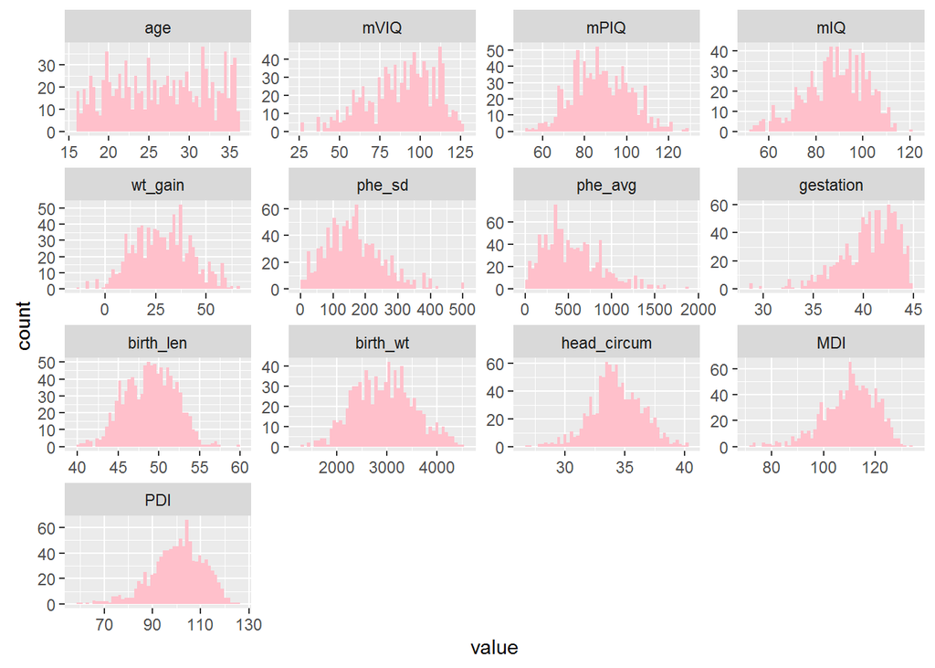

```r
ggplot(b,aes(x = value)) +
  facet_wrap(~variable,scales = "free")+
  geom_histogram(fill="pink",bins = 50)
```

```r
cor(na.omit(data))
```

```
##                      age         mVIQ          mPIQ          mIQ
## age          1.000000000 -0.020479701 -0.0063420604 -0.002130987
## mVIQ        -0.020479701  1.000000000  0.0200067424 -0.014478039
## mPIQ        -0.006342060  0.020006742  1.0000000000 -0.001084792
## mIQ         -0.002130987 -0.014478039 -0.0010847919  1.000000000
## wt_gain     -0.001183981 -0.073087926 -0.0007257826 -0.025961895
## phe_sd       0.051573008 -0.053950435  0.0895486190  0.052472935
## phe_avg     -0.046640433 -0.020625347 -0.0274222936 -0.010871096
## gestation    0.030971280 -0.025822072 -0.0257711445 -0.049819426
## birth_len    0.004855076 -0.044511142 -0.0264317824 -0.040233398
## birth_wt     0.006766176 -0.075419587 -0.0046401405 -0.034831547
## head_circum  0.092465322  0.019382655  0.0266516199 -0.022744153
## MDI          0.072354806 -0.006686547 -0.0016973701 -0.043133014
## PDI          0.076774506  0.003246112  0.0098748343 -0.030255923
##                   wt_gain      phe_sd     phe_avg   gestation    birth_len
## age         -0.0011839812  0.05157301 -0.04664043  0.03097128  0.004855076
## mVIQ        -0.0730879259 -0.05395044 -0.02062535 -0.02582207 -0.044511142
## mPIQ        -0.0007257826  0.08954862 -0.02742229 -0.02577114 -0.026431782
## mIQ         -0.0259618951  0.05247294 -0.01087110 -0.04981943 -0.040233398
## wt_gain      1.0000000000 -0.02125710 -0.02886797  0.03564905  0.027019457
## phe_sd      -0.0212571000  1.00000000  0.01476614 -0.01825789  0.090990605
## phe_avg     -0.0288679729  0.01476614  1.00000000  0.03283138  0.012698783
## gestation    0.0356490473 -0.01825789  0.03283138  1.00000000  0.048631727
## birth_len    0.0270194571  0.09099060  0.01269878  0.04863173  1.000000000
## birth_wt     0.9828910888 -0.02466845 -0.02723130  0.21734887  0.035771874
## head_circum  0.0421444520 -0.02584329 -0.19299902  0.13443637  0.027477932
## MDI          0.0533566977 -0.02865774 -0.42606941  0.83724160  0.042944534
## PDI          0.0533673002 -0.02855153 -0.69681295  0.63676669  0.029680213
##                 birth_wt head_circum          MDI          PDI
## age          0.006766176  0.09246532  0.072354806  0.076774506
## mVIQ        -0.075419587  0.01938266 -0.006686547  0.003246112
## mPIQ        -0.004640140  0.02665162 -0.001697370  0.009874834
## mIQ         -0.034831547 -0.02274415 -0.043133014 -0.030255923
## wt_gain      0.982891089  0.04214445  0.053356698  0.053367300
## phe_sd      -0.024668453 -0.02584329 -0.028657742 -0.028551533
## phe_avg     -0.027231303 -0.19299902 -0.426069415 -0.696812948
## gestation    0.217348869  0.13443637  0.837241604  0.636766690
## birth_len    0.035771874  0.02747793  0.042944534  0.029680213
## birth_wt     1.000000000  0.09085678  0.214810632  0.178953355
## head_circum  0.090856779  1.00000000  0.498460678  0.500117289
## MDI          0.214810632  0.49846068  1.000000000  0.944681287
## PDI          0.178953355  0.50011729  0.944681287  1.000000000
```

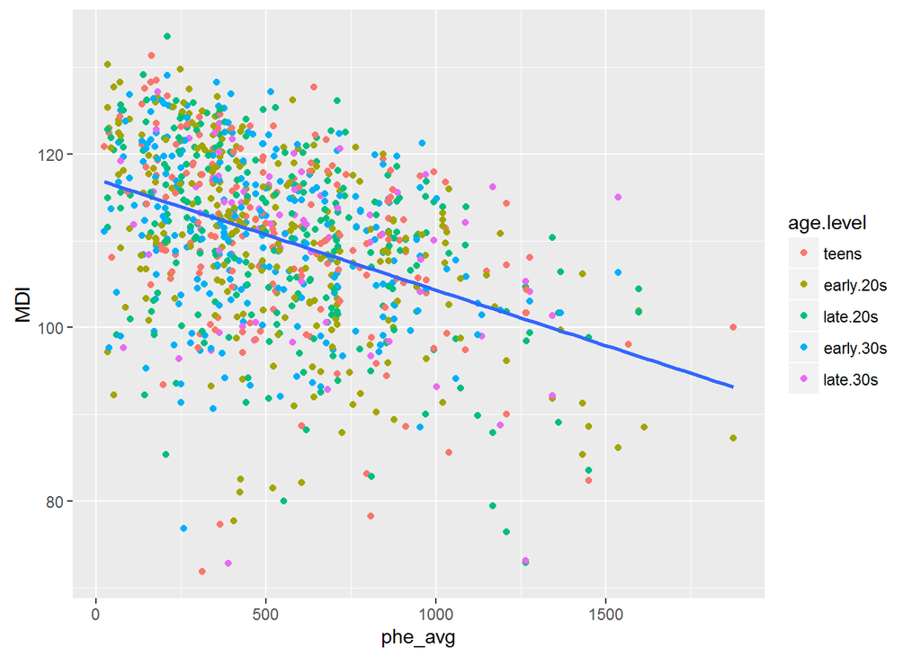

```r
data = mutate(data, age.level=factor(ifelse(data$age<20, "teens", ifelse(data$age<25,"early.20s",ifelse(data$age<30,"late.20s",ifelse(data$age<35,"early.30s","late.30s")))),levels = c("teens", "early.20s","late.20s", "early.30s", "late.30s"), ordered = T
))
ggplot(data=data, aes(x=phe_avg, y = MDI))+geom_point(aes(color = age.level))+
  geom_smooth(data=data, aes(x=phe_avg,y=MDI),method = "lm", se = F)
```

## Results

### Analysis on influential factors of children’s cognitive performance

```r
lm1 = lm(MDI ~ phe_avg, data =data)
summary(lm1)
```

```
##
## Call:
## lm(formula = MDI ~ phe_avg, data = data)
##
## Residuals:
##     Min      1Q  Median      3Q     Max
## -41.218  -5.394   1.348   6.800  19.103
##
## Coefficients:
##               Estimate Std. Error t value Pr(>|t|)
## (Intercept)  1.171e+02  5.751e-01  203.62   <2e-16 ***
## phe_avg     -1.278e-02  9.095e-04  -14.05   <2e-16 ***
## ---
## Signif. codes:  0 '***' 0.001 '**' 0.01 '*' 0.05 '.' 0.1 ' ' 1
##
## Residual standard error: 9.258 on 974 degrees of freedom
##   (24 observations deleted due to missingness)
## Multiple R-squared:  0.1686, Adjusted R-squared:  0.1677
## F-statistic: 197.4 on 1 and 974 DF,  p-value: < 2.2e-16
```

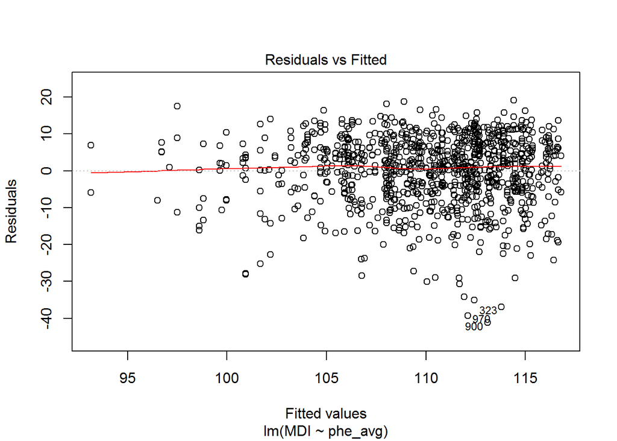

```r
plot(lm1,1)
```

- Average maternal Phe exposure is a significant preditor of children’s MDI at age 1.

```r
lm2 = lm(PDI ~ phe_avg, data =data)
summary(lm2)
```

```
##
## Call:
## lm(formula = PDI ~ phe_avg, data = data)
##
## Residuals:
##     Min      1Q  Median      3Q     Max
## -35.353  -4.691   1.144   5.769  17.324
##
## Coefficients:
##               Estimate Std. Error t value Pr(>|t|)
## (Intercept)  1.129e+02  4.946e-01  228.22   <2e-16 ***
## phe_avg     -2.291e-02  7.823e-04  -29.28   <2e-16 ***
## ---
## Signif. codes:  0 '***' 0.001 '**' 0.01 '*' 0.05 '.' 0.1 ' ' 1
##
## Residual standard error: 7.963 on 974 degrees of freedom
##   (24 observations deleted due to missingness)
## Multiple R-squared:  0.4682, Adjusted R-squared:  0.4676
## F-statistic: 857.5 on 1 and 974 DF,  p-value: < 2.2e-16
```

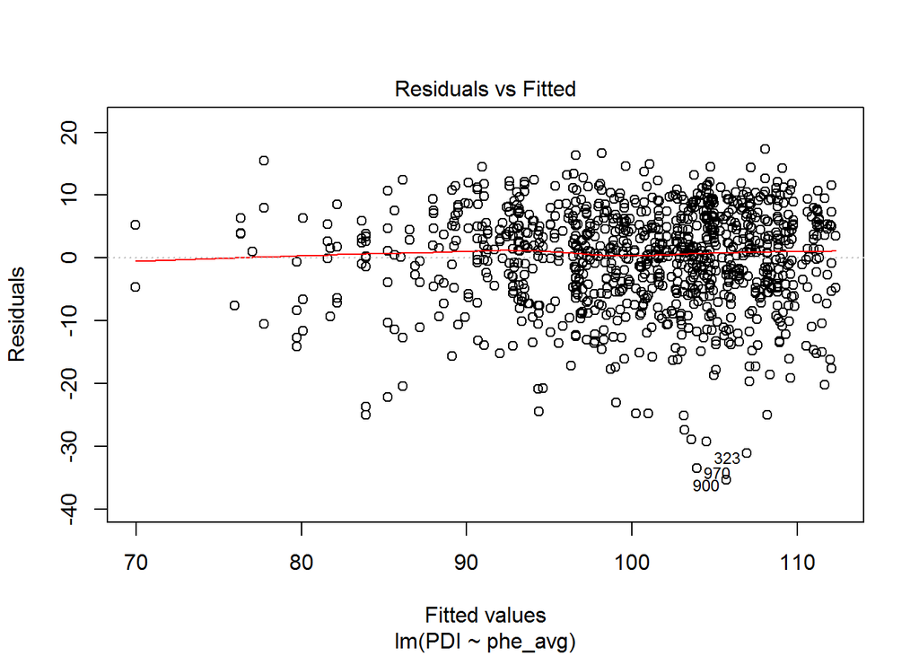

```r
plot(lm2,1)
```

- Average maternal Phe exposure is a significant preditor of children’s PDI at age 1.

When consider full model to observe other signficant variables:

```r
full1 = lm(MDI ~ . -PDI-age.level , data =data)
summary(full1)
```

```
##
## Call:
## lm(formula = MDI ~ . - PDI - age.level, data = data)
##
## Residuals:
##        Min         1Q     Median         3Q        Max
## -3.818e-12 -2.030e-14  1.300e-14  4.670e-14  4.720e-13
##
## Coefficients: (1 not defined because of singularities)
##               Estimate Std. Error    t value Pr(>|t|)
## (Intercept) -5.650e+01  2.734e-13 -2.066e+14  < 2e-16 ***
## age         -1.665e-15  1.640e-15 -1.015e+00  0.31034
## mVIQ         1.188e-15  4.549e-16  2.611e+00  0.00928 **
## mPIQ        -5.048e-16  7.089e-16 -7.120e-01  0.47669
## mIQ         -1.696e-15  7.508e-16 -2.258e+00  0.02431 *
## wt_gain     -8.786e+00  2.731e-14 -3.218e+14  < 2e-16 ***
## phe_sd       6.195e-17  1.078e-16  5.750e-01  0.56576
## phe_avg     -1.200e-02  2.949e-17 -4.069e+14  < 2e-16 ***
## gestation   -5.143e+00  2.601e-14 -1.977e+14  < 2e-16 ***
## birth_len    8.057e-16  3.126e-15  2.580e-01  0.79670
## birth_wt     2.143e-01  6.652e-16  3.221e+14  < 2e-16 ***
## head_circum         NA         NA         NA       NA
## ---
## Signif. codes:  0 '***' 0.001 '**' 0.01 '*' 0.05 '.' 0.1 ' ' 1
##
## Residual standard error: 2.256e-13 on 555 degrees of freedom
##   (434 observations deleted due to missingness)
## Multiple R-squared:      1,  Adjusted R-squared:      1
## F-statistic: 1.127e+29 on 10 and 555 DF,  p-value: < 2.2e-16
```

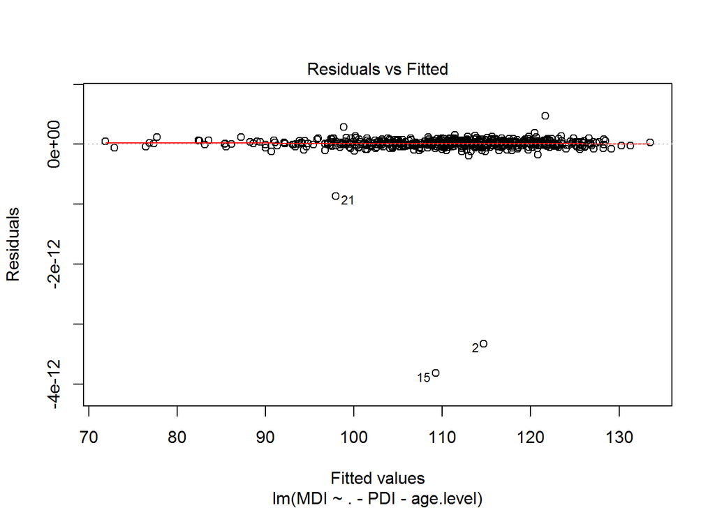

```r
plot(full1,1)
```

### Additional analysis on influential factors on newborn condition

```r
bwt_all = lm(birth_wt ~ . -MDI -PDI -age.level, data = data)
summary(bwt_all)
```

```
##
## Call:
## lm(formula = birth_wt ~ . - MDI - PDI - age.level, data = data)
##
## Residuals:
##        Min         1Q     Median         3Q        Max
## -2.045e-12 -1.866e-13 -3.760e-14  1.192e-13  1.781e-11
##
## Coefficients:
##               Estimate Std. Error    t value Pr(>|t|)
## (Intercept)  2.750e-12  9.992e-13  2.753e+00  0.00611 **
## age          6.175e-15  5.994e-15  1.030e+00  0.30335
## mVIQ        -4.064e-15  1.663e-15 -2.444e+00  0.01482 *
## mPIQ         2.008e-15  2.591e-15  7.750e-01  0.43853
## mIQ          7.159e-15  2.744e-15  2.609e+00  0.00932 **
## wt_gain      4.100e+01  2.547e-15  1.610e+16  < 2e-16 ***
## phe_sd      -3.002e-16  3.940e-16 -7.620e-01  0.44641
## phe_avg      4.371e-17  1.078e-16  4.050e-01  0.68527
## gestation    3.800e+01  1.297e-14  2.930e+15  < 2e-16 ***
## birth_len   -1.033e-15  1.142e-14 -9.000e-02  0.92797
## head_circum  7.000e+00  1.702e-14  4.113e+14  < 2e-16 ***
## ---
## Signif. codes:  0 '***' 0.001 '**' 0.01 '*' 0.05 '.' 0.1 ' ' 1
##
## Residual standard error: 8.246e-13 on 555 degrees of freedom
##   (434 observations deleted due to missingness)
## Multiple R-squared:      1,  Adjusted R-squared:      1
## F-statistic: 2.753e+31 on 10 and 555 DF,  p-value: < 2.2e-16
```

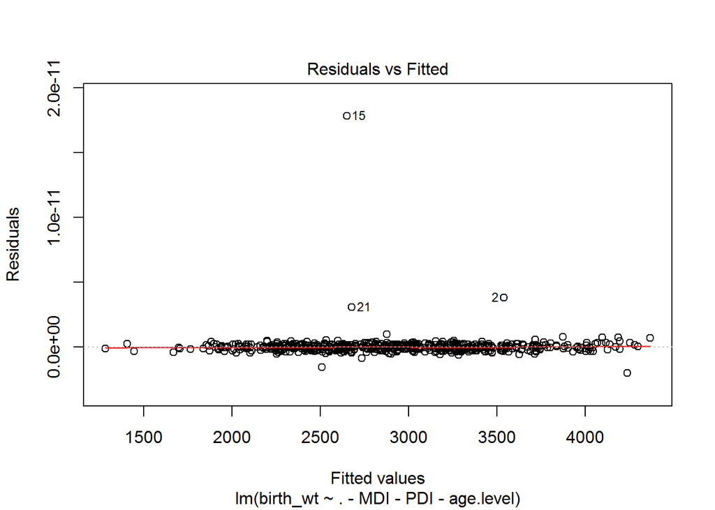

```r
plot(bwt_all,1)
```

```r
hcir_all = lm(head_circum ~ . -MDI -PDI -age.level, data = data)
summary(hcir_all)
```

```
##
## Call:
## lm(formula = head_circum ~ . - MDI - PDI - age.level, data = data)
##
## Residuals:
##        Min         1Q     Median         3Q        Max
## -2.546e-12 -1.708e-14  5.390e-15  2.662e-14  2.925e-13
##
## Coefficients:
##               Estimate Std. Error    t value Pr(>|t|)
## (Intercept) -3.294e-13  1.428e-13 -2.306e+00  0.02148 *
## age         -9.068e-16  8.568e-16 -1.058e+00  0.29032
## mVIQ         5.642e-16  2.376e-16  2.374e+00  0.01794 *
## mPIQ        -2.893e-16  3.703e-16 -7.810e-01  0.43500
## mIQ         -1.036e-15  3.922e-16 -2.642e+00  0.00848 **
## wt_gain     -5.857e+00  1.426e-14 -4.106e+14  < 2e-16 ***
## phe_sd       4.344e-17  5.632e-17  7.710e-01  0.44088
## phe_avg     -5.463e-18  1.541e-17 -3.550e-01  0.72303
## gestation   -5.429e+00  1.359e-14 -3.995e+14  < 2e-16 ***
## birth_len    1.353e-16  1.633e-15  8.300e-02  0.93399
## birth_wt     1.429e-01  3.475e-16  4.111e+14  < 2e-16 ***
## ---
## Signif. codes:  0 '***' 0.001 '**' 0.01 '*' 0.05 '.' 0.1 ' ' 1
##
## Residual standard error: 1.179e-13 on 555 degrees of freedom
##   (434 observations deleted due to missingness)
## Multiple R-squared:      1,  Adjusted R-squared:      1
## F-statistic: 1.811e+28 on 10 and 555 DF,  p-value: < 2.2e-16
```

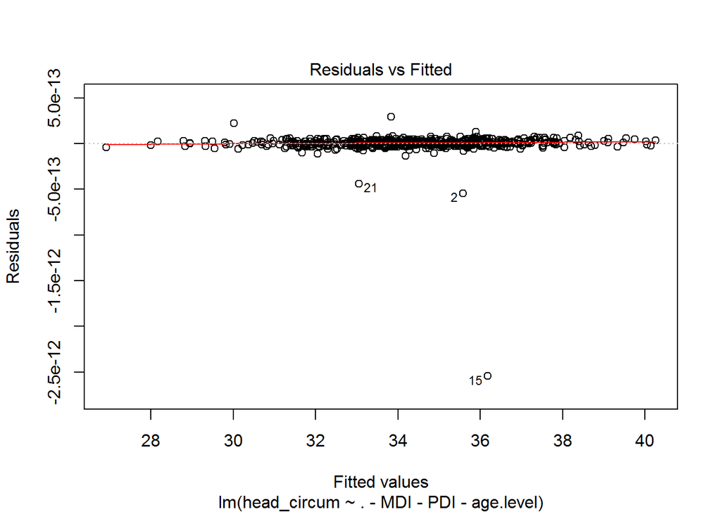

```r
plot(hcir_all,1)
```